# Homework 3 - 2

Xuechun Wang

5/5/2020

# Problem 2

## Part A

Use the Riboflavin dataset from Homework 1, and apply the **fsInf** and **fixedLassoInf** function from the **selectiveInference** R package to perform inference for forward stepwise regression and LASSO. For the **fixedLassoInf** function, use $\lambda.\min$ obtained from the **cv.glmnet** function from the **glmnet** R package. Compare and contrast the results from these two methods for inference.

```r
require(selectiveInference)
```

```r
riboflavin.x = read.csv("riboflavinx.csv")
riboflavin.y = read.csv("riboflaviny.csv")
riboflavin.x = riboflavin.x[-1]
riboflavin.y = riboflavin.y[-1]
y = riboflavin.y[,1]
```

```r
set.seed(666)
x = as.matrix(riboflavin.x)
y = as.matrix(y)
Forward_Stepwise  = fs(x,y)
output = fsInf(Forward_Stepwise)
output
```

```
##
## Call:
## fsInf(obj = Forward_Stepwise)
##
## Standard deviation of noise (specified or estimated) sigma = 0.920
##
## Sequential testing results with alpha = 0.100
##  Step  Var   Coef Z-score P-value LowConfPt UpConfPt LowTailArea
##     1 1278  0.697   5.433   0.080    -0.132    0.881       0.050
##     2 4003 -0.423  -3.817   0.110    -1.348    0.196       0.050
##     3 2564 -1.124  -2.755   0.319    -2.719    2.261       0.050
##     4   73 -0.316  -2.676   0.332    -1.023    0.741       0.050
##     5 2034  1.061   1.833   0.246    -2.604    7.033       0.050
##     6 1131  0.560   1.111   0.768    -9.664    1.610       0.050
##     7 1762 -0.596  -1.008   1.000    59.147      Inf       0.007
##     8 2186  0.617   0.927   0.004    66.569      Inf       0.011
##     9 3495  0.279   0.699   0.004    39.858      Inf       0.027
##    10 3499 -0.586  -0.775   0.006      -Inf  -75.625       0.000
##    11 1595  0.649   0.804   0.987      -Inf  -80.672       0.000
##    12 3138  0.465   0.654   0.956      -Inf   -4.767       0.000
##    13 1774 -0.302  -0.551   0.014      -Inf  -31.314       0.000
##    14  681 -0.088  -0.493   0.697    -7.901      Inf       0.050
##    15 3579  0.297   0.502   0.991      -Inf  -59.238       0.000
##    16 1017  0.166   0.495   0.004    33.663      Inf       0.013
##    17 2354  0.213   0.465   0.995      -Inf  -45.871       0.000
##    18 3670  0.074   0.372   0.989      -Inf  -11.820       0.000
##    19  330  0.288   0.389   0.007    74.034      Inf       0.036
##    20   90 -0.099  -0.336   0.041      -Inf   -6.848       0.000
##    21 1977 -0.247  -0.292   0.061      -Inf   43.446       0.000
##    22   16 -0.134  -0.313   0.992    42.881      Inf       0.041
##    23  648  0.217   0.334   0.027    64.883      Inf       0.042
##    24 1142  0.300   0.325   0.995      -Inf  -92.416       0.000
##    25 2641 -0.239  -0.309   0.061      -Inf    6.613       0.000
##    26  825 -0.124  -0.252   0.839      -Inf      Inf       0.000
##    27 3384 -0.164  -0.260   0.015      -Inf  -56.001       0.000
##    28  678  0.075   0.178   0.059   -20.097      Inf       0.050
##    29 2335 -0.099  -0.179   0.269      -Inf      Inf       0.000
##    30 1158  0.185   0.211   0.020    48.321      Inf       0.050
##    31 2435  0.168   0.177   0.068   -63.287      Inf       0.050
##    32 3654  0.139   0.160   0.485      -Inf      Inf       0.000
```

[output cut: 96 more lines]

```
##       0.000
##       0.000
##       0.000
##       0.000
##       0.000
##       0.038
##       0.000
##       0.000
##       0.000
##       0.000
##       0.000
##       0.000
##       0.000
##
## Estimated stopping point from ForwardStop rule = 2
```

```r
options(warn = -1)
require(glmnet)
x = scale(x,center=T,scale=T)
lambdas = cv.glmnet(x,y)
sigmas = estimateSigma(x,y,intercept = T,standardize = T)$sigmahat
min_lambda = lambdas$lambda.min
betas = coef(lambdas, x=x, y=y, s = sigmas, exact=TRUE,thresh=1E-20)[-1]
output_fixed = fixedLassoInf(x,y,betas,min_lambda)
output_fixed
```

```
##
## Call:
## fixedLassoInf(x = x, y = y, beta = betas, lambda = min_lambda)
##
## Standard deviation of noise (specified or estimated) sigma = 0.920
##
## Testing results at lambda = 0.030, with alpha = 0.100
##
##   Var   Coef Z-score P-value LowConfPt UpConfPt LowTailArea UpTailArea
##   624 -0.158  -1.060       0      -Inf  -14.897           0          0
##  1278  0.163   0.849       1      -Inf  -19.239           0          0
##  1312  0.166   0.918       1      -Inf  -18.057           0          0
##  1502 -0.084  -0.520       1    16.197      Inf           0          0
##  1516  0.226   1.645       0    13.731      Inf           0          0
##  1588  0.029   0.184       1    15.955      Inf           0          0
##  2564 -0.166  -1.069       1    15.561      Inf           0          0
##  4003 -0.337  -2.269       0      -Inf  -14.841           0          0
##
## Note: coefficients shown are partial regression coefficients
```

## Part B

Use UMAP to visualize both the row set and the column set from the Riboflavin design matrix – that is, visualize the patients and also the gene expressions across the patients. Do this for the raw data, and also for the data after standardization of the variables. Compare these embeddings with embeddings from $t$-SNE.

### UMAP

#### For row data:

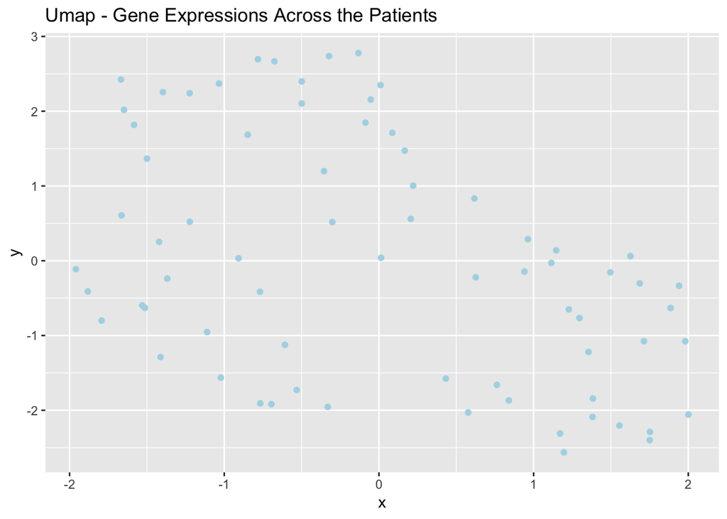

```r
library(ggplot2)
library(umap)
x = as.matrix(riboflavin.x)
set.seed(1230)
embeddings = umap(x)

df <- data.frame(x = embeddings$layout[,1],
                 y = embeddings$layout[,2])

# visualize the gene expressions
p = ggplot(df, aes(x = x, y= y)) + geom_point(color = "lightblue")
p+ggtitle("Umap - Gene Expressions Across the Patients")
```

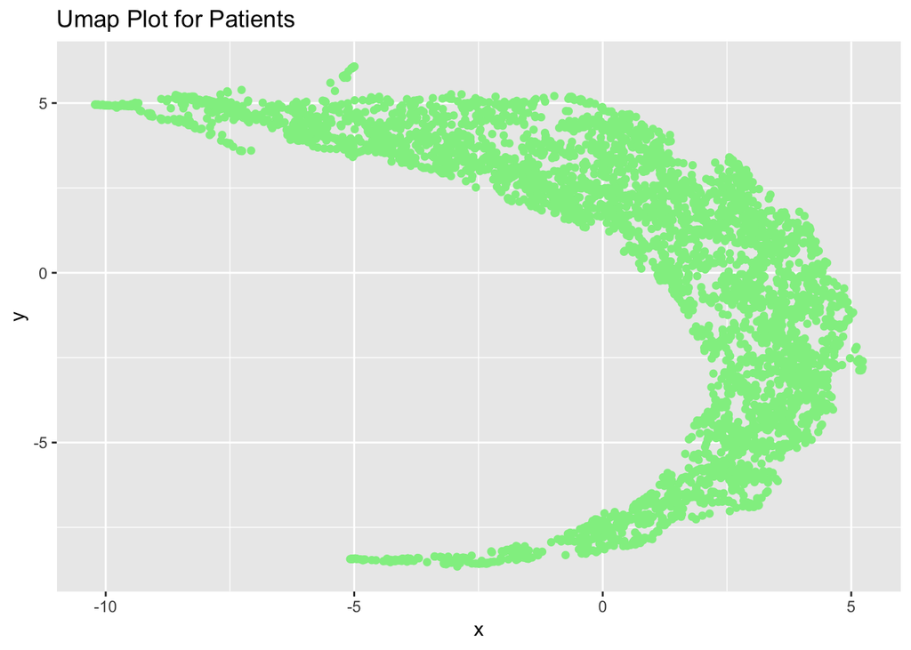

```r
X.T = t(x)
set.seed(123)
patients = umap(X.T)
df2 <- data.frame(x = patients$layout[,1],
                 y = patients$layout[,2])

pat_plot = ggplot(df2, aes(x = x, y= y)) + geom_point(color = "lightgreen")
pat_plot+ggtitle("Umap Plot for Patients")
```

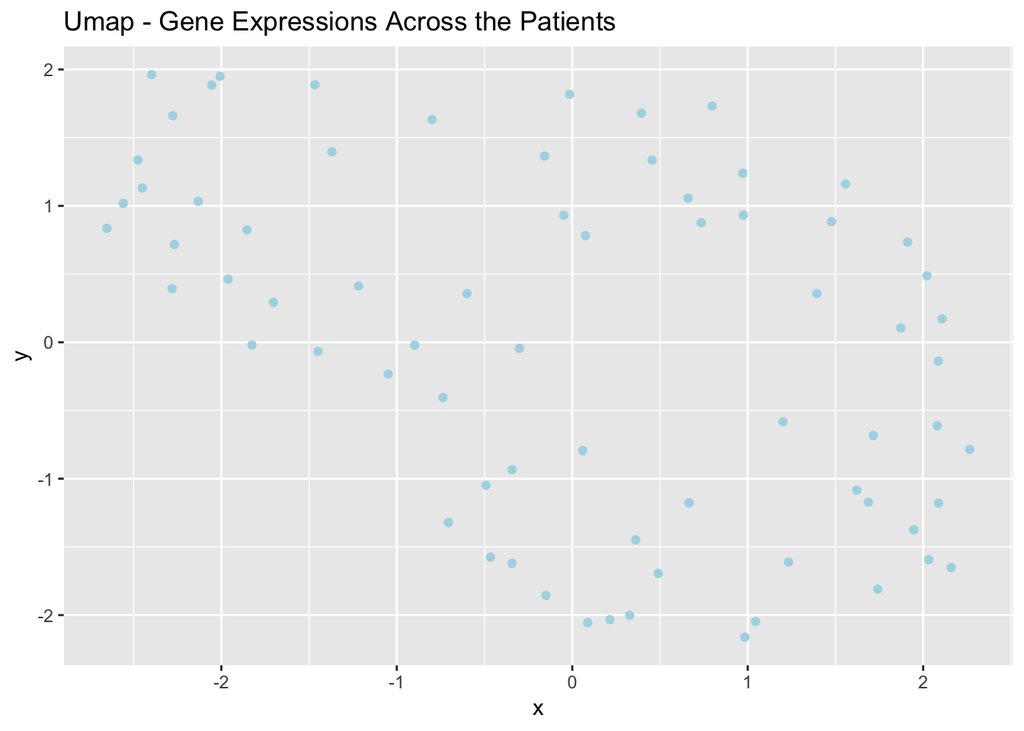

```r
library(umap)
library(ggplot2)
set.seed(666)
embeddings = umap(x)

df <- data.frame(x = embeddings$layout[,1],
                 y = embeddings$layout[,2])

# visualize the gene expressions
gene_plot = ggplot(df, aes(x = x, y= y)) + geom_point(color = "lightblue")
gene_plot+ggtitle("Umap - Gene Expressions Across the Patients")
```

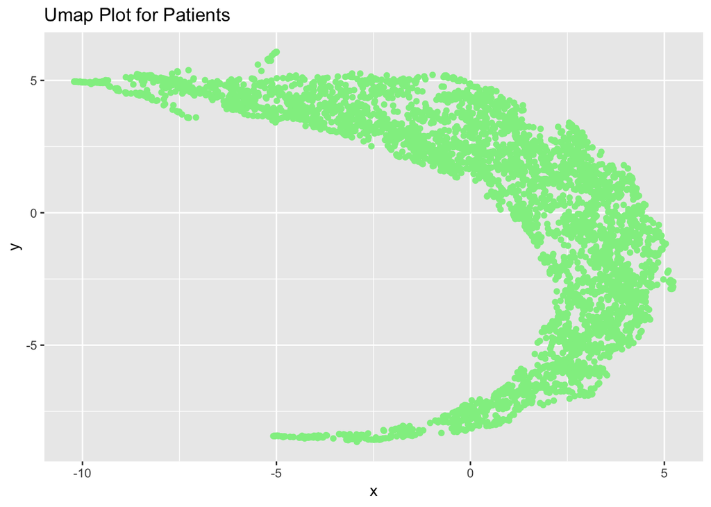

```r
#  patients visualization
X.T = t(x)
set.seed(123)
patients = umap(X.T)
df2 <- data.frame(x = patients$layout[,1],
                 y = patients$layout[,2])

pat_plot = ggplot(df2, aes(x = x, y= y)) + geom_point(color = "lightgreen")
pat_plot+ggtitle("Umap Plot for Patients")
```

### t-SNE

#### For row data:

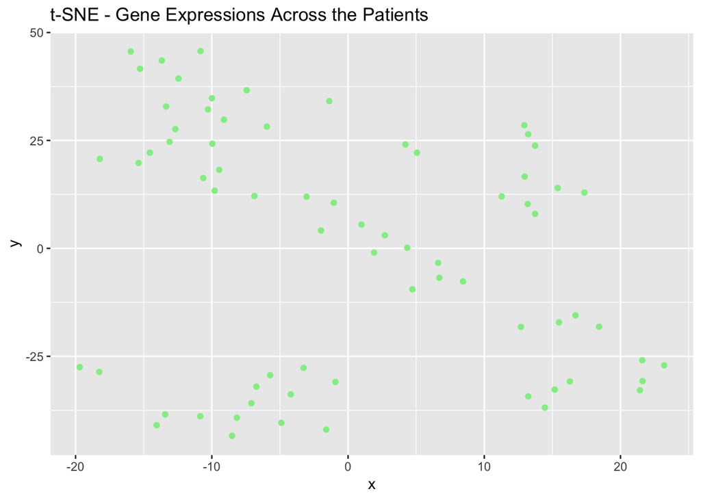

```r
library(Rtsne)
tsne_gene = Rtsne(x, perplexity = 6)

df3 = data.frame(x = tsne_gene$Y[,1],
                 y = tsne_gene$Y[,2])

ggplot(df3, aes(x, y)) + geom_point(color = "lightgreen") + ggtitle("t-SNE - Gene Expressions Across the Patients")
```

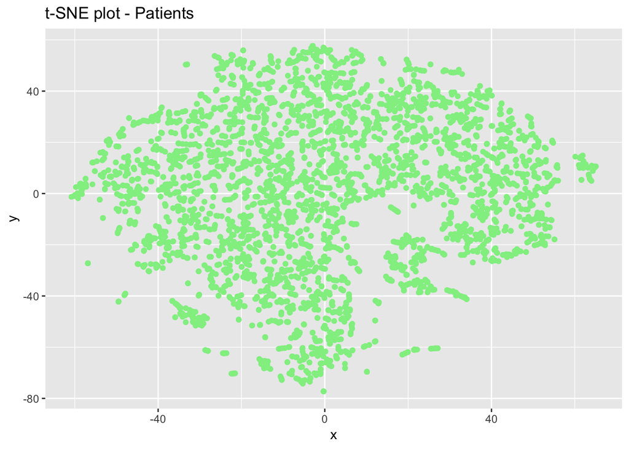

```r
library(Rtsne)

tsne_patient = Rtsne(t(x), perplexity = 6)

df3 = data.frame(x = tsne_patient$Y[,1],
                 y = tsne_patient$Y[,2])

ggplot(df3, aes(x, y)) + geom_point(color = "lightgreen") + ggtitle("t-SNE plot - Patients")
```

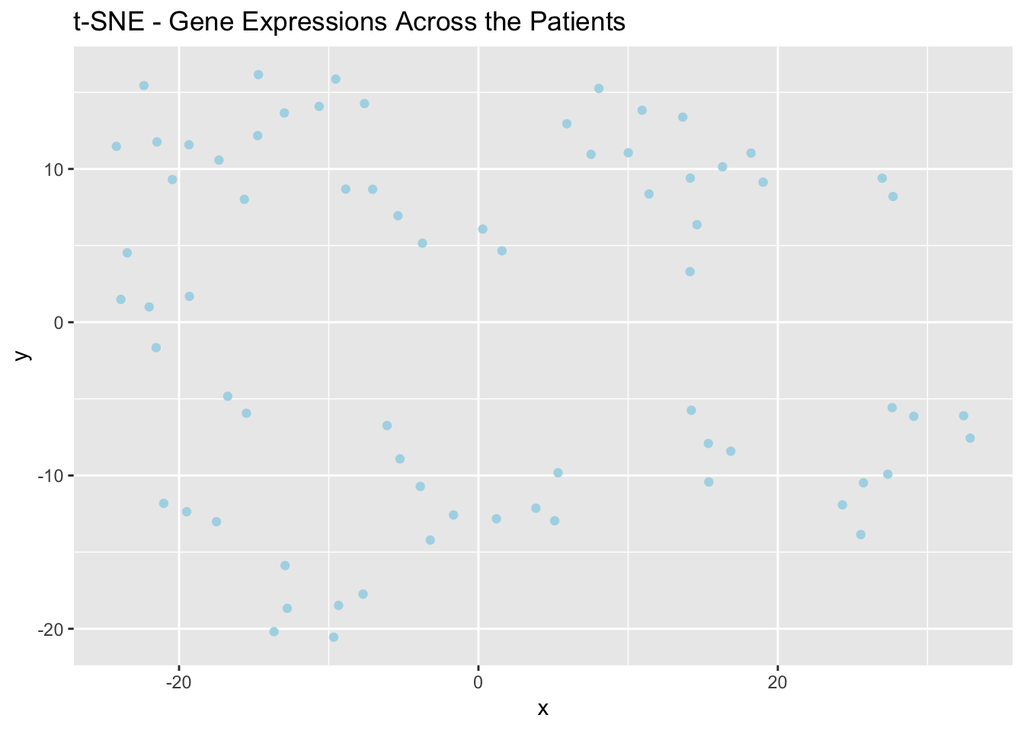

```r
scaled_tx = scale(t(x),center=T,scale=T)
tsne_gene = Rtsne(x, perplexity = 6)
scaled_x = scale(x,center=T,scale=T)
df3 = data.frame(x = tsne_gene$Y[,1],
                 y = tsne_gene$Y[,2])

ggplot(df3, aes(x, y)) + geom_point(color = "lightblue") + ggtitle("t-SNE - Gene Expressions Across the Patients")
```

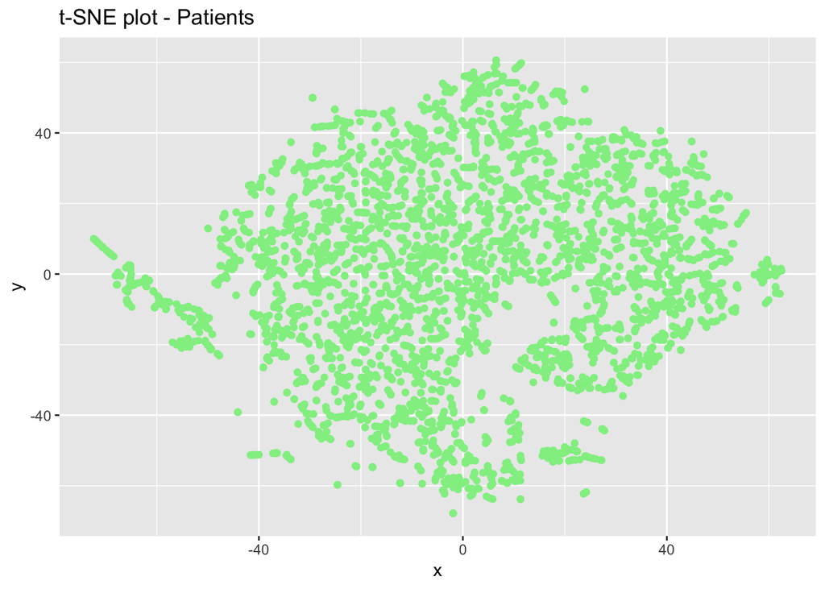

```r
tsne_patient = Rtsne(scaled_tx, perplexity = 6)

df3 = data.frame(x = tsne_patient$Y[,1],
                 y = tsne_patient$Y[,2])

ggplot(df3, aes(x, y)) + geom_point(color = "lightgreen") + ggtitle("t-SNE plot - Patients")
```